# Time SeriesForecasting - Semester End Exam - 100 marks

# Section B Total 40 Marks

# Dataset: `power_usage`

Your task is to analyze the **power usage** to better understand consumption patterns over time. For this, we have gathered load data for the period of **January 2015 to December 2016**.

The dataset includes daily records of electricity load over the specified period. This data can be useful for:

- Analyzing trends
- Forecasting future load
- Understanding seasonal variations in electricity usage

```python
import pandas                          as      pd
import numpy                           as      np
import matplotlib.pyplot               as      plt
from   IPython.display                 import  display
from   pylab                           import  rcParams
from   datetime                        import  datetime, timedelta
from   pandas.tseries.offsets          import BDay
from statsmodels.tsa.stattools         import  adfuller
from statsmodels.tsa.stattools         import  pacf
from statsmodels.tsa.stattools         import  acf
from statsmodels.graphics.tsaplots     import  plot_pacf
from statsmodels.graphics.tsaplots     import  plot_acf
from statsmodels.graphics.gofplots     import  qqplot
from statsmodels.tsa.seasonal          import  seasonal_decompose
from   statsmodels.tsa.api             import  ExponentialSmoothing,Holt
from statsmodels.tsa.arima.model       import  ARIMA
from sklearn.metrics                   import  mean_squared_error
import warnings
warnings.filterwarnings('ignore')
%matplotlib inline
import itertools
```

# Section B Total 40 Marks

### 2.A Data preparation (10 marks)

#### a. Read the dataset (tab, csv, xls, txt, inbuilt dataset). What are the number of rows and no. of cols & types of variables? (2 MARK)

```python
import pandas as pd
df=pd.read_csv("power_usage2.csv")


rows, cols = df.shape
data_types = df.dtypes

print(f"Number of rows: {rows}")
print(f"Number of columns: {cols}")
print("\nData types of variables:\n", data_types)
```

```
Number of rows: 731
Number of columns: 2

Data types of variables:
 date       object
demand    float64
dtype: object
```

```python
df.head(10)
```

|  | date | demand |
| --- | --- | --- |
| 0 | 2015-01-01 | 99635.030 |
| 1 | 2015-01-02 | 129606.010 |
| 2 | 2015-01-03 | 142300.540 |
| 3 | 2015-01-04 | 104330.715 |
| 4 | 2015-01-05 | 118132.200 |
| 5 | 2015-01-06 | 130672.485 |
| 6 | 2015-01-07 | 153514.820 |
| 7 | 2015-01-08 | 142015.655 |
| 8 | 2015-01-09 | 121801.155 |
| 9 | 2015-01-10 | 103043.660 |

#### b. convert the data into time series (3 MARK)

```python
#df = pd.read_csv('power_usage.csv', index_col = 'date')
```

```python
#df.index = pd.to_datetime(df['date'], format='%m/%d/%y')  # Convert 'date' to datetime and set as index
df.index = pd.to_datetime(df['date'])
df.drop("date", axis=1, inplace=True)
```

```python
df.head()
```

| date | demand |
| --- | --- |
| 2015-01-01 | 99635.030 |
| 2015-01-02 | 129606.010 |
| 2015-01-03 | 142300.540 |
| 2015-01-04 | 104330.715 |
| 2015-01-05 | 118132.200 |

#### c. Check for defects in the data such as missing values, null, etc. (2 MARK)

```python
# Checking for missing values
missing_values = df.isnull().sum()
print("Missing values in each column:\n", missing_values)
```

```
Missing values in each column:
 demand    0
dtype: int64
```

```python
# Checking if the data is sorted by date
is_sorted = df.index.is_monotonic_increasing

if is_sorted:
    print("The data is sorted by date.")
else:
    print("The data is NOT sorted by date.")
```

```
The data is sorted by date.
```

```python
'''
df.sort_index(inplace=True)
print("Data has been sorted by date.")
'''
```

```python
## If there is missing value  we can use following technique - ffill , bfill, mean , linear interpolation , time based interpolation
## short forcast using  ARIMA
'''
 # Forward fill
    df['demand'] = df['demand'].fillna(method='ffill')

    # Backward fill
    df['demand'] = df['demand'].fillna(method='bfill')

    # Mean imputation
    df['demand'] = df['demand'].fillna(df['demand'].mean())

    # Median imputation
    df['demand'] = df['demand'].fillna(df['demand'].median())

    # Linear interpolation
    df['demand'] = df['demand'].interpolate(method='linear')

    # Time-based interpolation
    df['demand'] = df['demand'].interpolate(method='time')

    from statsmodels.tsa.arima.model import ARIMA

    # Fit ARIMA model to predict missing values
    model = ARIMA(df['demand'], order=(1, 1, 1))  # Adjust order as needed
    fitted_model = model.fit()
    forecast = fitted_model.predict(start=missing_start, end=missing_end)
    df.loc[df['demand'].isnull(), 'demand'] = forecast

'''
```

#### d. Visualize the time series using relevant plots. (3 MARK)

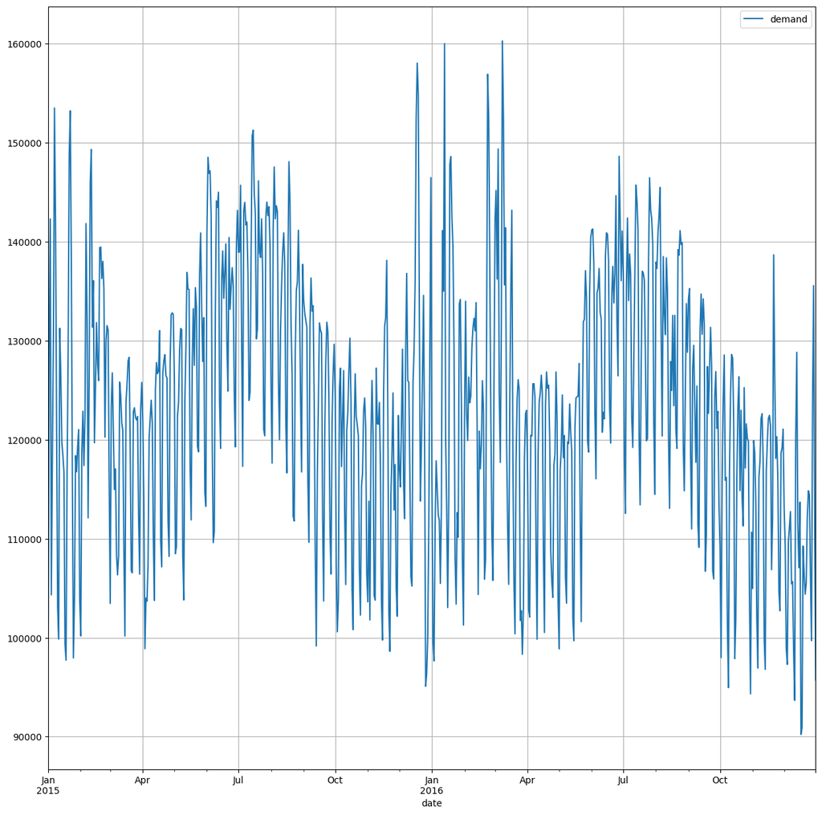

```python
df.plot(figsize=(15,15),grid=True)
```

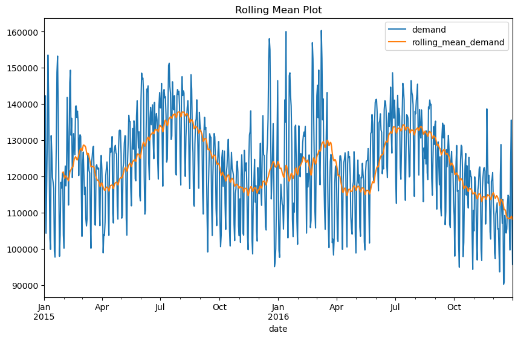

```python
df['rolling_mean_demand'] = df['demand'].rolling(window=30).mean()
df[['demand', 'rolling_mean_demand']].plot(figsize=(10, 6), title='Rolling Mean Plot')
```

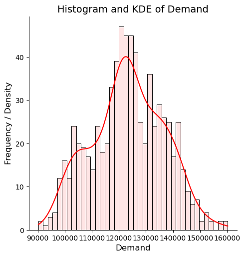

```python
import seaborn as sns
import matplotlib.pyplot as plt

# Set the figure size
plt.figure(figsize=(8, 5))

# Create a distplot using Seaborn
sns.displot(
    df['demand'],
    bins=40,
    kde=True,
    color='red',  # Histogram color
    #kde_kws={'color': 'red', 'linewidth': 2},  # KDE line settings
    alpha=0.1  # Transparency for histogram
)

# Add title and labels
plt.title('Histogram and KDE of Demand', fontsize=14)
plt.xlabel('Demand', fontsize=12)
plt.ylabel('Frequency / Density', fontsize=12)

# Show the plot
plt.show()
```

### 2.B Data Understanding (15 marks)

#### a. Decompose the time series and check for components of time series. (4 MARKS)

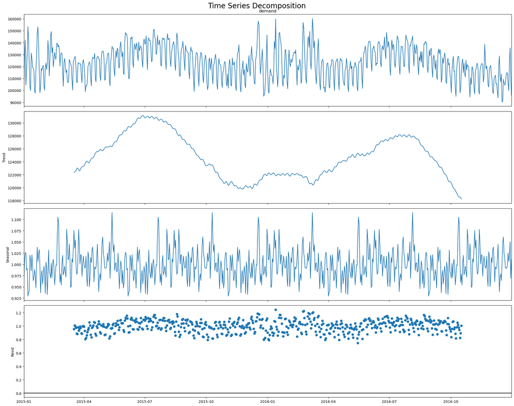

```python
from statsmodels.tsa.seasonal import seasonal_decompose
import matplotlib.pyplot as plt

# Filter the time series data for the specified date range
data = df['demand']

# Decompose the time series using the multiplicative model
decomposition = seasonal_decompose(data, model='multiplicative', period=150)

# Plot the decomposed components with a larger figure size
fig = decomposition.plot()
fig.set_size_inches(20, 16)  # Adjust the figure size for better visibility
plt.suptitle('Time Series Decomposition', fontsize=20)  # Larger title font
plt.tight_layout()  # Adjust layout to avoid overlap
plt.show()
```

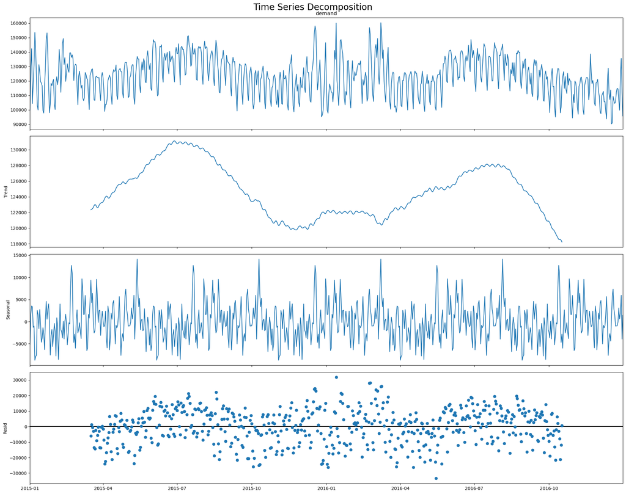

```python
from statsmodels.tsa.seasonal import seasonal_decompose
import matplotlib.pyplot as plt

# Filter the time series data for the specified date range
data = df['demand']

# Decompose the time series using the multiplicative model
decomposition = seasonal_decompose(data, model='additive', period=150)

# Plot the decomposed components with a larger figure size
fig = decomposition.plot()
fig.set_size_inches(20, 16)  # Adjust the figure size for better visibility
plt.suptitle('Time Series Decomposition', fontsize=20)  # Larger title font
plt.tight_layout()  # Adjust layout to avoid overlap
plt.show()
```

Based on the visual representation of the time series decomposition, it appears that the multiplicative model is more likely to be a better fit for this data.

Here's why:

Original Time Series = Trend * Seasonality * Residual This means that the seasonal fluctuations are proportional to the level of the trend.

In an additive model, the time series is decomposed as:

Original Time Series = Trend + Seasonality + Residual Here, the seasonal component is added to the trend, which would result in a more constant amplitude of the seasonal fluctuations regardless of the trend.

To confirm this, you could:

Calculate the residuals for both additive and multiplicative models. Analyze the residuals for patterns or trends. A good model should have residuals that are random and white noise. Use statistical tests to compare the goodness-of-fit of the two models.

#### b. Perform dicky fuller test to check the stationarity? What other actions will you take if series is non-stationary? (3+2 MARKS)

```python
from statsmodels.tsa.stattools import adfuller

def dickey_fuller_test(tsf_df, column_name):
    # Remove NaN values from the series
    ts_data = tsf_df[column_name].dropna()

    result = adfuller(ts_data)
    print('ADF Statistic: %f' % result[0])
    print('p-value: %f' % result[1])
    print('Critical Values:')
    for key, value in result[4].items():
        print('\t%s: %.3f' % (key, value))
    print(f"P-value: {result[1]}")
    # Interpret the results
    if result[1] <= 0.05:
        print("Strong evidence against the null hypothesis")
        print("Reject the null hypothesis")
        print("Data has no unit root and is stationary")
    else:
        print("Weak evidence against the null hypothesis")
        print("Fail to reject the null hypothesis")
        print("Data has a unit root and is non-stationary")
```

```python
dickey_fuller_test(df,'demand')
```

```
ADF Statistic: -2.308027
p-value: 0.169392
Critical Values:
	1%: -3.440
	5%: -2.866
	10%: -2.569
P-value: 0.16939212767807926
Weak evidence against the null hypothesis
Fail to reject the null hypothesis
Data has a unit root and is non-stationary
```

## Since the Time is not stationary - we need to bring it to stationary by first order differentiating

```python
df['demand_diff1'] = df['demand'].diff()
```

```python
dickey_fuller_test(df,'demand_diff1')
```

```
ADF Statistic: -7.814829
p-value: 0.000000
Critical Values:
	1%: -3.440
	5%: -2.866
	10%: -2.569
P-value: 6.914638590426314e-12
Strong evidence against the null hypothesis
Reject the null hypothesis
Data has no unit root and is stationary
```

# As we can see with first order differencing the unit root and non stationarity can be removed

#### c. Plot AutoCorrelation and Partial AutoCorrelation function for original series? What is your inference from these plots? (3+3 MARKS)

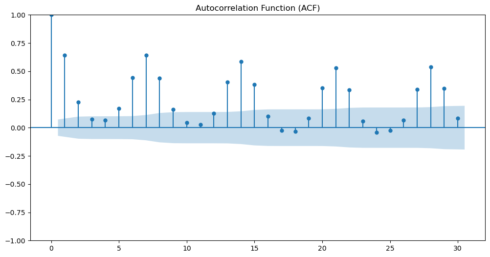

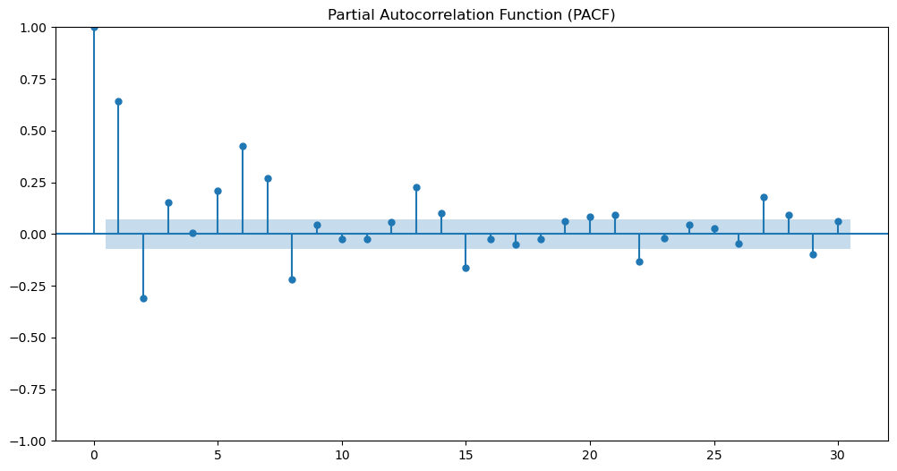

```python
# Plot ACF
fig, ax = plt.subplots(figsize=(12, 6))
plot_acf(df['demand'], lags=30, ax=ax)  # Adjust 'lags' as needed
plt.title('Autocorrelation Function (ACF)')
plt.show()

# Plot PACF
fig, ax = plt.subplots(figsize=(12, 6))
plot_pacf(df['demand'], lags=30, ax=ax)  # Adjust 'lags' as needed
plt.title('Partial Autocorrelation Function (PACF)')
plt.show()
```

### 2.C Model Building (15 marks)

#### a. Split dataset into train and test sets. Use last two months of data for testing. (5 marks)

```python
import pandas as pd
import numpy as np
from statsmodels.tsa.arima.model import ARIMA
from sklearn.metrics import mean_squared_error, mean_absolute_percentage_error
import matplotlib.pyplot as plt
```

```python
# Split dataset into train and test
test_size = 61  # Approximately two months
train = df.iloc[:-test_size]
test = df.iloc[-test_size:]
```

```python
train.head()
```

| date | demand | rolling_mean_demand | demand_diff1 |
| --- | --- | --- | --- |
| 2015-01-01 | 99635.030 | NaN | NaN |
| 2015-01-02 | 129606.010 | NaN | 29970.980 |
| 2015-01-03 | 142300.540 | NaN | 12694.530 |
| 2015-01-04 | 104330.715 | NaN | -37969.825 |
| 2015-01-05 | 118132.200 | NaN | 13801.485 |

```python
train.tail()
```

| date | demand | rolling_mean_demand | demand_diff1 |
| --- | --- | --- | --- |
| 2016-10-27 | 120142.430 | 116478.680333 | -1462.965 |
| 2016-10-28 | 119820.710 | 116434.595667 | -321.720 |
| 2016-10-29 | 104191.105 | 115812.349500 | -15629.605 |
| 2016-10-30 | 94325.720 | 115175.214333 | -9865.385 |
| 2016-10-31 | 110661.430 | 115224.553333 | 16335.710 |

```python
test.head()
```

| date | demand | rolling_mean_demand | demand_diff1 |
| --- | --- | --- | --- |
| 2016-11-01 | 104976.210 | 115457.329333 | -5685.220 |
| 2016-11-02 | 119904.480 | 115592.845000 | 14928.270 |
| 2016-11-03 | 118677.495 | 115412.445833 | -1226.985 |
| 2016-11-04 | 113666.485 | 114916.049167 | -5011.010 |
| 2016-11-05 | 101810.750 | 114446.456167 | -11855.735 |

```python
test.tail()
```

| date | demand | rolling_mean_demand | demand_diff1 |
| --- | --- | --- | --- |
| 2016-12-27 | 99701.430 | 108340.078667 | -6583.400 |
| 2016-12-28 | 123693.520 | 108507.650333 | 23992.090 |
| 2016-12-29 | 135571.795 | 109054.404500 | 11878.275 |
| 2016-12-30 | 112141.830 | 108756.879167 | -23429.965 |
| 2016-12-31 | 95728.150 | 108180.350167 | -16413.680 |

#### b. Fit ARIMA model and observe the RMSE and MAPE values of the model for test data.(10 marks)

```
Best ARIMA order: (4, 0, 4)
Best AIC: 13964.32960649859
RMSE: 11536.433956281187
MAPE: 0.09%
```

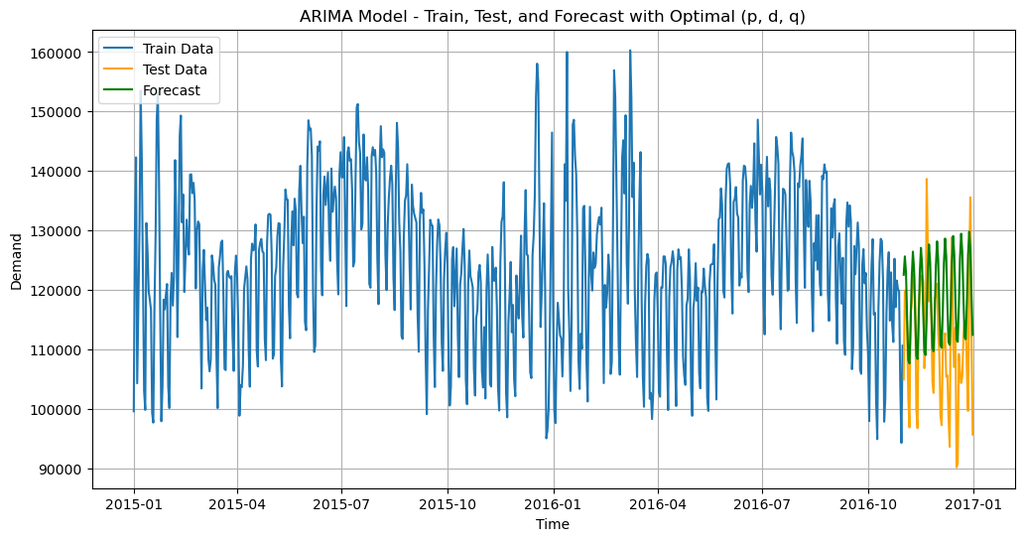

```python
import numpy as np
import pandas as pd
from statsmodels.tsa.arima.model import ARIMA
import warnings

warnings.filterwarnings("ignore")  # To ignore warnings during grid search

# Define the range of p, d, and q
p_values = range(0, 5)  # Adjust range as needed
d_values = range(0, 3)
q_values = range(0, 5)

# Initialize variables to store the best model
best_aic = float("inf")
best_order = None
best_model = None

# Grid search for p, d, q
for p in p_values:
    for d in d_values:
        for q in q_values:
            try:
                # Fit ARIMA model
                model = ARIMA(train['demand'], order=(p, d, q))
                model_fit = model.fit()

                # Check AIC
                aic = model_fit.aic
                if aic < best_aic:
                    best_aic = aic
                    best_order = (p, d, q)
                    best_model = model_fit
            except:
                continue

# Print the best p, d, q and corresponding AIC
print(f"Best ARIMA order: {best_order}")
print(f"Best AIC: {best_aic}")

# Use the best model for forecasting
forecast = best_model.forecast(steps=len(test))

# Calculate RMSE and MAPE
from sklearn.metrics import mean_squared_error
rmse = np.sqrt(mean_squared_error(test['demand'], forecast))
#mape = np.mean(np.abs((test['demand'] - forecast) / test['demand'])) * 100
mape = mean_absolute_percentage_error(test['demand'], forecast)
print(f"RMSE: {rmse}")
print(f"MAPE: {mape:.2f}%")

# Plot the results
import matplotlib.pyplot as plt
plt.figure(figsize=(12, 6))
plt.plot(train['demand'], label='Train Data')
plt.plot(test['demand'], label='Test Data', color='orange')
plt.plot(test.index, forecast, label='Forecast', color='green')
plt.xlabel('Time')
plt.ylabel('Demand')
plt.title('ARIMA Model - Train, Test, and Forecast with Optimal (p, d, q)')
plt.legend(loc='upper left')
plt.grid(True)
plt.show()
```

```
p=0, d=0, q=0 - AIC: 18294.783603281827
p=0, d=0, q=1 - AIC: 14231.999538597704
p=0, d=0, q=2 - AIC: 14175.317472323619
p=0, d=0, q=3 - AIC: 14215.185251297915
p=0, d=0, q=4 - AIC: 14219.193689705651
p=0, d=0, q=5 - AIC: 14212.314858248323
p=0, d=1, q=0 - AIC: 14380.136804000264
p=0, d=1, q=1 - AIC: 14360.945253308157
p=0, d=1, q=2 - AIC: 14219.891687844698
p=0, d=1, q=3 - AIC: 14168.455560180064
p=0, d=1, q=4 - AIC: 14164.056529606307
p=0, d=1, q=5 - AIC: 14156.03840247704
p=0, d=2, q=0 - AIC: 14751.531608878966
p=0, d=2, q=1 - AIC: 14403.074253270011
p=0, d=2, q=2 - AIC: 14370.960114575944
p=0, d=2, q=3 - AIC: 14264.317844073452
p=0, d=2, q=4 - AIC: 14217.849808156017
p=0, d=2, q=5 - AIC: 14222.69820788818
p=1, d=0, q=0 - AIC: 14269.786851877025
p=1, d=0, q=1 - AIC: 14183.305095875527
p=1, d=0, q=2 - AIC: 14177.37736872895
p=1, d=0, q=3 - AIC: 14154.592963005323
p=1, d=0, q=4 - AIC: 14149.62742872864
p=1, d=0, q=5 - AIC: 14126.546728289715
p=1, d=1, q=0 - AIC: 14372.026735541169
p=1, d=1, q=1 - AIC: 14351.10576845237
p=1, d=1, q=2 - AIC: 14232.097147780118
p=1, d=1, q=3 - AIC: 14162.789626472339
p=1, d=1, q=4 - AIC: 14152.87782563478
p=1, d=1, q=5 - AIC: 14152.18352874593
p=1, d=2, q=0 - AIC: 14713.415314548536
p=1, d=2, q=1 - AIC: 14388.403346387655
p=1, d=2, q=2 - AIC: 14363.615252626692
p=1, d=2, q=3 - AIC: 14371.721314212988
p=1, d=2, q=4 - AIC: 14219.411400411265
p=1, d=2, q=5 - AIC: 14219.374187933407
p=2, d=0, q=0 - AIC: 14187.669695212808
p=2, d=0, q=1 - AIC: 14180.104731927422
p=2, d=0, q=2 - AIC: 14161.706399230541
p=2, d=0, q=3 - AIC: 14055.022957585134
```

[output cut: 57 more lines]

```
p=5, d=1, q=1 - AIC: 14082.08954995142
p=5, d=1, q=2 - AIC: 14074.37417658805
p=5, d=1, q=3 - AIC: 14001.405174860522
p=5, d=1, q=4 - AIC: 13951.978557342827
p=5, d=1, q=5 - AIC: 13952.819307100437
p=5, d=2, q=0 - AIC: 14407.725544378049
p=5, d=2, q=1 - AIC: 14155.516212470702
p=5, d=2, q=2 - AIC: 14098.623702881941
p=5, d=2, q=3 - AIC: 14057.65958884963
p=5, d=2, q=4 - AIC: 13996.48819500608
p=5, d=2, q=5 - AIC: 13990.393630391778
Best ARIMA order: (5, 0, 5)
Best AIC: 13874.649125016029
RMSE: 14339.90092744678
MAPE: 0.12%
```

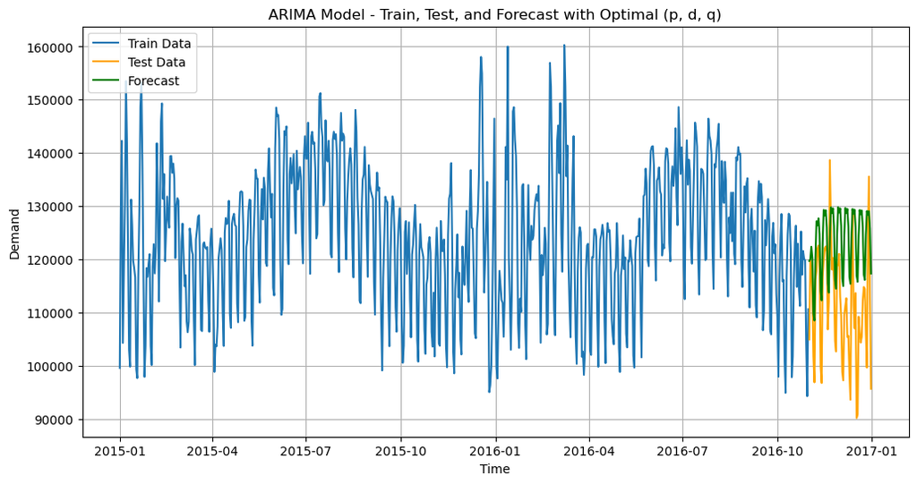

```python
# detailed code - choose one
import numpy as np
import pandas as pd
from statsmodels.tsa.arima.model import ARIMA
import warnings
from sklearn.metrics import mean_squared_error, mean_absolute_percentage_error
import matplotlib.pyplot as plt

warnings.filterwarnings("ignore")  # To ignore warnings during grid search

# Define the range of p, d, and q
p_values = range(0, 6)  # Adjust range as needed
d_values = range(0, 3)
q_values = range(0, 6)

# Initialize variables to store the best model
best_aic = float("inf")
best_order = None
best_model = None

# Grid search for p, d, q
for p in p_values:
    for d in d_values:
        for q in q_values:
            try:
                # Fit ARIMA model
                model = ARIMA(train['demand'], order=(p, d, q))
                model_fit = model.fit()

                # Check AIC
                aic = model_fit.aic
                print(f"p={p}, d={d}, q={q} - AIC: {aic}")  # Print AIC for each combination

                if aic < best_aic:
                    best_aic = aic
                    best_order = (p, d, q)
                    best_model = model_fit
            except:
                continue

# Print the best p, d, q and corresponding AIC
print(f"Best ARIMA order: {best_order}")
print(f"Best AIC: {best_aic}")

# Use the best model for forecasting
forecast = best_model.forecast(steps=len(test))

# Calculate RMSE and MAPE
rmse = np.sqrt(mean_squared_error(test['demand'], forecast))
mape = mean_absolute_percentage_error(test['demand'], forecast)
print(f"RMSE: {rmse}")
print(f"MAPE: {mape:.2f}%")

# Plot the results
plt.figure(figsize=(12, 6))
plt.plot(train['demand'], label='Train Data')
plt.plot(test['demand'], label='Test Data', color='orange')
plt.plot(test.index, forecast, label='Forecast', color='green')
plt.xlabel('Time')
plt.ylabel('Demand')
plt.title('ARIMA Model - Train, Test, and Forecast with Optimal (p, d, q)')
plt.legend(loc='upper left')
plt.grid(True)
plt.show()
```

# Section C Total 40 Marks

```python
df["demand"].head(100)
```

```
date
2015-01-01     99635.030
2015-01-02    129606.010
2015-01-03    142300.540
2015-01-04    104330.715
2015-01-05    118132.200
                 ...
2015-04-06    107383.370
2015-04-07    120235.505
2015-04-08    122129.775
2015-04-09    123990.760
2015-04-10    121753.115
Name: demand, Length: 100, dtype: float64
```

### 3.A Fit exponential smoothing model and observe the residuals, RMSE and MAPE values of the model for test data. (15 MARKS)

```
RMSE: 12343.26
MAPE: 9.11%
```

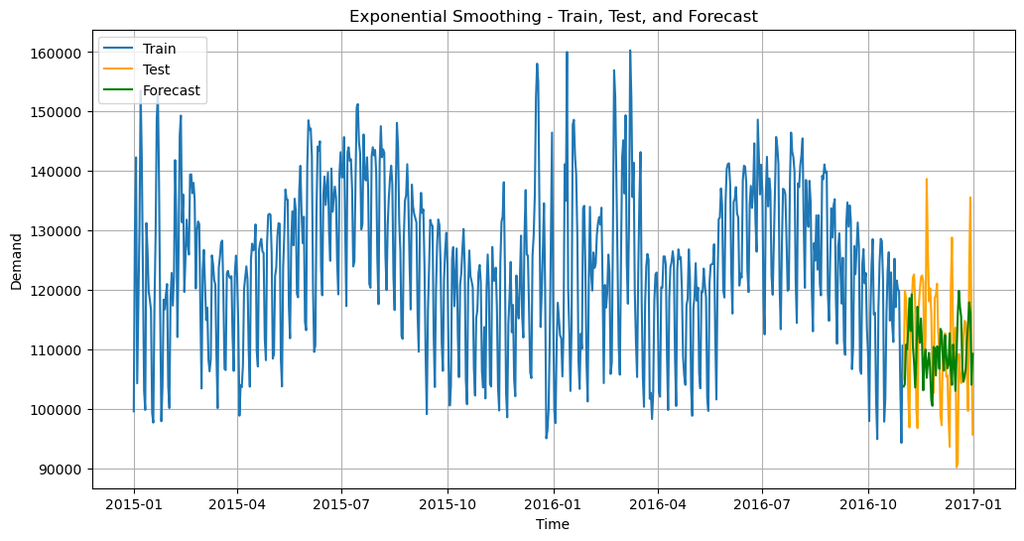

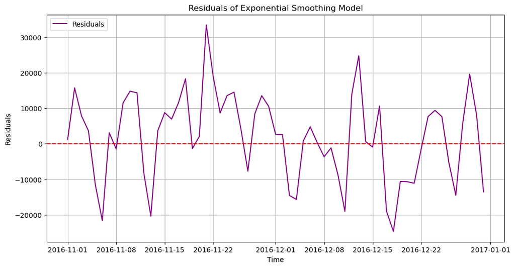

ExponentialSmoothing Model Results

| Dep. Variable: | demand | No. Observations: | 670 |
| --- | --- | --- | --- |
| Model: | ExponentialSmoothing | SSE | 81386381695.366 |
| Optimized: | True | AIC | 12780.181 |
| Trend: | Additive | BIC | 13474.302 |
| Seasonal: | Multiplicative | AICC | 12875.667 |
| Seasonal Periods: | 150 | Date: | Sat, 18 Jan 2025 |
| Box-Cox: | False | Time: | 23:47:15 |
| Box-Cox Coeff.: | None |  |  |

|  | coeff | code | optimized |
| --- | --- | --- | --- |
| smoothing_level | 0.9950000 | alpha | True |
| smoothing_trend | 0.0001 | beta | True |
| smoothing_seasonal | 0.0001 | gamma | True |
| initial_level | 1.2247e+05 | l.0 | True |
| initial_trend | 37.362513 | b.0 | True |
| initial_seasons.0 | 0.9162458 | s.0 | True |
| initial_seasons.1 | 0.9797197 | s.1 | True |
| initial_seasons.2 | 1.0033433 | s.2 | True |
| initial_seasons.3 | 1.0003501 | s.3 | True |
| initial_seasons.4 | 1.0050821 | s.4 | True |
| initial_seasons.5 | 1.0219237 | s.5 | True |
| initial_seasons.6 | 0.9116759 | s.6 | True |
| initial_seasons.7 | 0.8985209 | s.7 | True |
| initial_seasons.8 | 0.9151244 | s.8 | True |
| initial_seasons.9 | 1.0071348 | s.9 | True |
| initial_seasons.10 | 0.9911546 | s.10 | True |
| initial_seasons.11 | 1.0023950 | s.11 | True |
| initial_seasons.12 | 1.0708135 | s.12 | True |
| initial_seasons.13 | 0.9961771 | s.13 | True |
| initial_seasons.14 | 0.9424654 | s.14 | True |
| initial_seasons.15 | 0.9670233 | s.15 | True |
| initial_seasons.16 | 1.0068563 | s.16 | True |
| initial_seasons.17 | 0.9708551 | s.17 | True |
| initial_seasons.18 | 0.9689242 | s.18 | True |
| initial_seasons.19 | 1.0491454 | s.19 | True |
| initial_seasons.20 | 1.0367429 | s.20 | True |
| initial_seasons.21 | 0.9831715 | s.21 | True |
| initial_seasons.22 | 1.0171060 | s.22 | True |
| initial_seasons.23 | 1.0192405 | s.23 | True |
| initial_seasons.24 | 0.9763420 | s.24 | True |

[output cut: 125 more lines]

```python
import numpy as np
import matplotlib.pyplot as plt
from statsmodels.tsa.holtwinters import ExponentialSmoothing
from sklearn.metrics import mean_squared_error, mean_absolute_percentage_error



# Fit Exponential Smoothing model
model = ExponentialSmoothing(
    train['demand'],
    seasonal='mul',  # Change to 'add' or 'mul' if you know the seasonality
    trend='add',    # Can also use 'mul' or None depending on the data
    seasonal_periods=150,  # Define the seasonality period explicitly
    initialization_method='estimated'
)

model_fit = model.fit(optimized=True)

# Forecast for the test set
forecast = model_fit.forecast(steps=len(test))

# Align the indices of the forecast to match the test set
forecast = pd.Series(forecast, index=test.index)

# Calculate residuals
residuals = test['demand'] - forecast

# Calculate RMSE and MAPE
rmse = np.sqrt(mean_squared_error(test['demand'], forecast))
mape = mean_absolute_percentage_error(test['demand'], forecast)

# Print metrics
print(f"RMSE: {rmse:.2f}")
print(f"MAPE: {mape:.2%}")

# Plot Train, Test, and Forecast
plt.figure(figsize=(12, 6))
plt.plot(train['demand'], label='Train')
plt.plot(test['demand'], label='Test', color='orange')
plt.plot(forecast, label='Forecast', color='green')
plt.legend(loc='upper left')
plt.title('Exponential Smoothing - Train, Test, and Forecast')
plt.xlabel('Time')
plt.ylabel('Demand')
plt.grid(True)
plt.show()

# Plot residuals
plt.figure(figsize=(12, 6))
plt.plot(residuals, label='Residuals', color='purple')
plt.axhline(y=0, color='red', linestyle='--')
plt.legend(loc='upper left')
plt.title('Residuals of Exponential Smoothing Model')
plt.xlabel('Time')
plt.ylabel('Residuals')
plt.grid(True)
plt.show()

model_fit.summary()
```

```python
model_fit.summary()
```

ExponentialSmoothing Model Results

| Dep. Variable: | demand | No. Observations: | 670 |
| --- | --- | --- | --- |
| Model: | ExponentialSmoothing | SSE | 81386381695.366 |
| Optimized: | True | AIC | 12780.181 |
| Trend: | Additive | BIC | 13474.302 |
| Seasonal: | Multiplicative | AICC | 12875.667 |
| Seasonal Periods: | 150 | Date: | Sat, 18 Jan 2025 |
| Box-Cox: | False | Time: | 23:20:25 |
| Box-Cox Coeff.: | None |  |  |

|  | coeff | code | optimized |
| --- | --- | --- | --- |
| smoothing_level | 0.9950000 | alpha | True |
| smoothing_trend | 0.0001 | beta | True |
| smoothing_seasonal | 0.0001 | gamma | True |
| initial_level | 1.2247e+05 | l.0 | True |
| initial_trend | 37.362513 | b.0 | True |
| initial_seasons.0 | 0.9162458 | s.0 | True |
| initial_seasons.1 | 0.9797197 | s.1 | True |
| initial_seasons.2 | 1.0033433 | s.2 | True |
| initial_seasons.3 | 1.0003501 | s.3 | True |
| initial_seasons.4 | 1.0050821 | s.4 | True |
| initial_seasons.5 | 1.0219237 | s.5 | True |
| initial_seasons.6 | 0.9116759 | s.6 | True |
| initial_seasons.7 | 0.8985209 | s.7 | True |
| initial_seasons.8 | 0.9151244 | s.8 | True |
| initial_seasons.9 | 1.0071348 | s.9 | True |
| initial_seasons.10 | 0.9911546 | s.10 | True |
| initial_seasons.11 | 1.0023950 | s.11 | True |
| initial_seasons.12 | 1.0708135 | s.12 | True |
| initial_seasons.13 | 0.9961771 | s.13 | True |
| initial_seasons.14 | 0.9424654 | s.14 | True |
| initial_seasons.15 | 0.9670233 | s.15 | True |
| initial_seasons.16 | 1.0068563 | s.16 | True |
| initial_seasons.17 | 0.9708551 | s.17 | True |
| initial_seasons.18 | 0.9689242 | s.18 | True |
| initial_seasons.19 | 1.0491454 | s.19 | True |
| initial_seasons.20 | 1.0367429 | s.20 | True |
| initial_seasons.21 | 0.9831715 | s.21 | True |
| initial_seasons.22 | 1.0171060 | s.22 | True |
| initial_seasons.23 | 1.0192405 | s.23 | True |
| initial_seasons.24 | 0.9763420 | s.24 | True |

[output cut: 125 more lines]

### 3.B How would you improve the exponential smoothing model? Make the changes and Fit the final exponential smoothing model. (10 MARKS)

```python
from sklearn.metrics import mean_squared_error, mean_absolute_percentage_error
import numpy as np
from statsmodels.tsa.holtwinters import ExponentialSmoothing
from itertools import product

# Fixed parameters
alpha = 0.9950000  # Smoothing level
beta = 0.0001      # Smoothing trend
gamma = 0.0001     # Smoothing seasonality

# Hyperparameter ranges for tuning
trend_options = ['add', 'mul']  # Trend options
seasonal_options = ['add', 'mul']  # Seasonal options
seasonal_periods_range = np.arange(149, 158, 1)  # Seasonal periods range
damped_trend_options = [True, False]  # Damped trend options

best_rmse = float('inf')
best_mape = float('inf')
best_params = None

# Generate all combinations of parameters for the specified hyperparameters
param_grid = product(
    trend_options,
    seasonal_options,
    seasonal_periods_range,
    damped_trend_options
)

# Iterate over all combinations of the parameters
for trend, seasonal, seasonal_periods, damped_trend in param_grid:
    try:
        # Fit model with current parameters
        model = ExponentialSmoothing(
            train['demand'],
            trend=trend,
            seasonal=seasonal,
            seasonal_periods=seasonal_periods,
            damped_trend=damped_trend,
            initialization_method='estimated'
        )
        model_fit = model.fit(
            smoothing_level=alpha,
            smoothing_slope=beta,
            smoothing_seasonal=gamma,
            optimized=False  # Turn off automatic optimization
        )

        # Forecast and calculate RMSE and MAPE
        forecast = model_fit.forecast(steps=len(test))
        rmse = np.sqrt(mean_squared_error(test['demand'], forecast))
        mape = mean_absolute_percentage_error(test['demand'], forecast)

        # Check if this is the best model so far
        if rmse < best_rmse:
            best_rmse = rmse
            best_mape = mape
            best_params = (trend, seasonal, seasonal_periods, damped_trend)
    except Exception as e:
        # Skip invalid parameter combinations
        print(f"Skipping parameters (trend={trend}, seasonal={seasonal}, seasonal_periods={seasonal_periods}, damped_trend={damped_trend}): {e}")
        continue

# Output the best parameters, RMSE, and MAPE
print(f"Best Parameters: {best_params}")
print(f"Best RMSE: {best_rmse:.2f}")
print(f"Best MAPE: {best_mape:.2%}")
```

[output not shown]

### Best Parameters: ('add', 'mul', 154, False)

### Best RMSE: 7789.78

### Best MAPE: 5.26%

# Building Final Model with Best Param

```
Final Model RMSE: 7789.78
Final Model MAPE: 5.26%
```

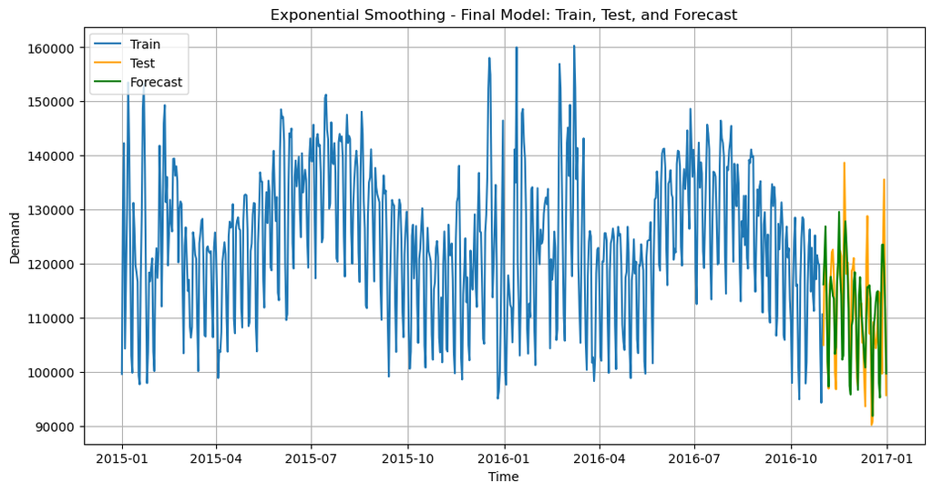

```python
from sklearn.metrics import mean_squared_error, mean_absolute_percentage_error
import numpy as np
from statsmodels.tsa.holtwinters import ExponentialSmoothing
import matplotlib.pyplot as plt


# Best parameters from hyperparameter tuning
alpha = 0.9950000  # Smoothing level
beta = 0.0001      # Smoothing trend
gamma = 0.0001     # Smoothing seasonality
trend = 'add'
seasonal = 'mul'
seasonal_periods = 154  # Seasonal period
damped_trend = False  # No damped trend

# Fit the final Exponential Smoothing model with the best parameters
model_final = ExponentialSmoothing(
    train['demand'],
    trend=trend,
    seasonal=seasonal,
    seasonal_periods=seasonal_periods,
    damped_trend=damped_trend,
    initialization_method='estimated'
)

# Fit the model with the fixed parameters
model_fit_final = model_final.fit(
    smoothing_level=alpha,
    smoothing_slope=beta,
    smoothing_seasonal=gamma,
    optimized=False  # Turn off automatic optimization as we are using fixed parameters
)

# Forecast for the test set
forecast_final = model_fit_final.forecast(steps=len(test))

# Calculate RMSE (Root Mean Squared Error)
rmse_final = np.sqrt(mean_squared_error(test['demand'], forecast_final))

# Calculate MAPE (Mean Absolute Percentage Error)
mape_final = mean_absolute_percentage_error(test['demand'], forecast_final)

# Print the RMSE and MAPE
print(f"Final Model RMSE: {rmse_final:.2f}")
print(f"Final Model MAPE: {mape_final:.2%}")



# Plot the forecasted values
plt.figure(figsize=(12, 6))
plt.plot(train['demand'], label='Train')
plt.plot(test['demand'], label='Test', color='orange')
plt.plot(forecast_final, label='Forecast', color='green')
plt.legend(loc='upper left')
plt.title('Exponential Smoothing - Final Model: Train, Test, and Forecast')
plt.xlabel('Time')
plt.ylabel('Demand')
plt.grid(True)
plt.show()
```

```python
model_fit_final.summary()
```

ExponentialSmoothing Model Results

| Dep. Variable: | demand | No. Observations: | 670 |
| --- | --- | --- | --- |
| Model: | ExponentialSmoothing | SSE | 32195428416.067 |
| Optimized: | False | AIC | 12166.834 |
| Trend: | Additive | BIC | 12878.984 |
| Seasonal: | Multiplicative | AICC | 12268.053 |
| Seasonal Periods: | 154 | Date: | Sat, 18 Jan 2025 |
| Box-Cox: | False | Time: | 23:48:01 |
| Box-Cox Coeff.: | None |  |  |

|  | coeff | code | optimized |
| --- | --- | --- | --- |
| smoothing_level | 0.9950000 | alpha | False |
| smoothing_trend | 0.0001 | beta | False |
| smoothing_seasonal | 0.0001 | gamma | False |
| initial_level | 1.2293e+05 | l.0 | False |
| initial_trend | 6.1288843 | b.0 | False |
| initial_seasons.0 | 1.0728280 | s.0 | False |
| initial_seasons.1 | 1.0418017 | s.1 | False |
| initial_seasons.2 | 0.8966810 | s.2 | False |
| initial_seasons.3 | 0.8427432 | s.3 | False |
| initial_seasons.4 | 0.9611600 | s.4 | False |
| initial_seasons.5 | 1.0166738 | s.5 | False |
| initial_seasons.6 | 1.0478031 | s.6 | False |
| initial_seasons.7 | 1.0568788 | s.7 | False |
| initial_seasons.8 | 1.0370962 | s.8 | False |
| initial_seasons.9 | 0.9009204 | s.9 | False |
| initial_seasons.10 | 0.8564581 | s.10 | False |
| initial_seasons.11 | 1.0308668 | s.11 | False |
| initial_seasons.12 | 1.0667635 | s.12 | False |
| initial_seasons.13 | 1.0523053 | s.13 | False |
| initial_seasons.14 | 1.0760782 | s.14 | False |
| initial_seasons.15 | 1.0269933 | s.15 | False |
| initial_seasons.16 | 0.9118292 | s.16 | False |
| initial_seasons.17 | 0.8799271 | s.17 | False |
| initial_seasons.18 | 0.9592038 | s.18 | False |
| initial_seasons.19 | 0.9887486 | s.19 | False |
| initial_seasons.20 | 1.0133384 | s.20 | False |
| initial_seasons.21 | 1.0074332 | s.21 | False |
| initial_seasons.22 | 1.0023323 | s.22 | False |
| initial_seasons.23 | 0.8893829 | s.23 | False |
| initial_seasons.24 | 0.8552663 | s.24 | False |

[output cut: 129 more lines]

### 3.B Analyze the residuals of this final model. Feel free to use charts or graphs to explain. (5 MARKS)

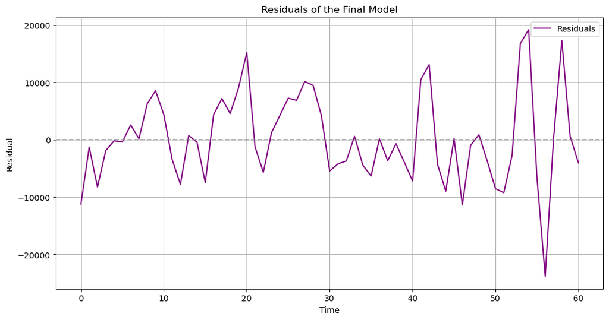

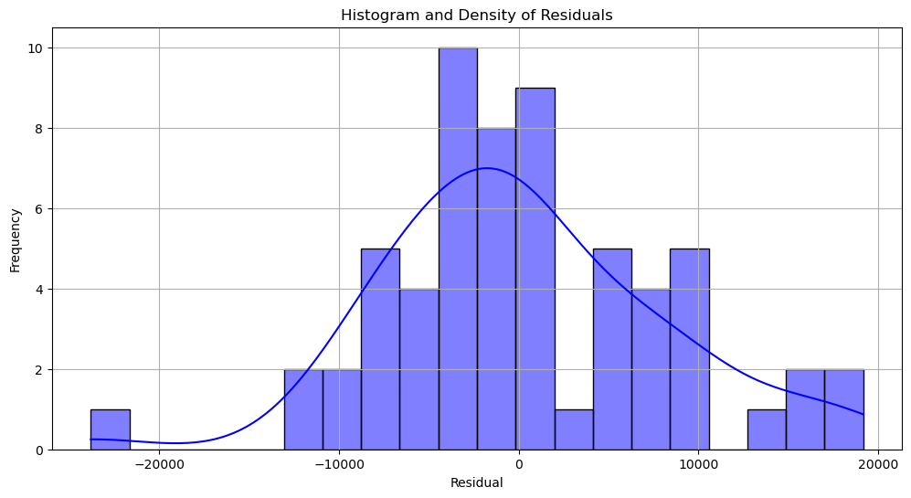

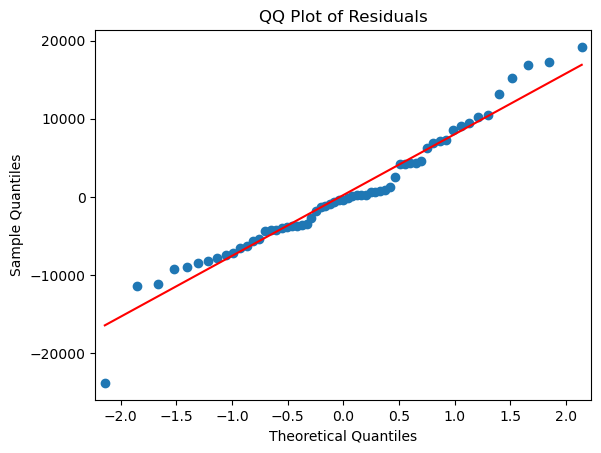

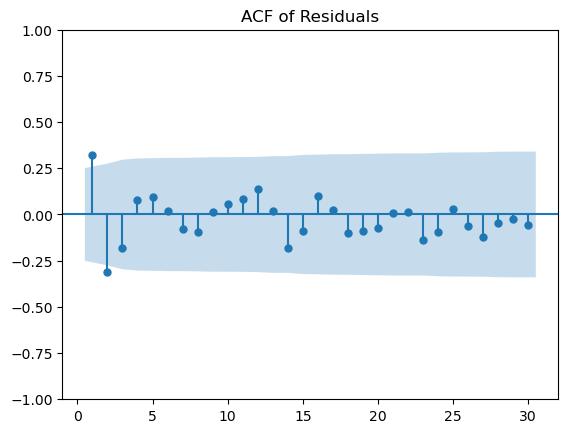

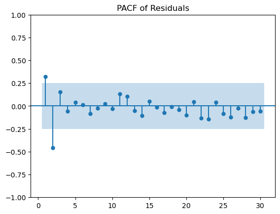

```
Residual Summary Statistics:
count       61.000000
mean       220.383198
std       7851.281849
min     -23819.079640
25%      -4225.297509
50%       -381.856545
75%       4383.537941
max      19181.293402
Name: Residuals, dtype: float64

Ljung-Box Test for Autocorrelation:
      lb_stat  lb_pvalue
10  17.388326   0.066201
```

```python
import matplotlib.pyplot as plt
import seaborn as sns
from statsmodels.graphics.tsaplots import plot_acf, plot_pacf
from statsmodels.graphics.gofplots import qqplot
from statsmodels.stats.diagnostic import acorr_ljungbox
import pandas as pd

# Calculate residuals (difference between actual and forecasted values)
residuals = test['demand'].values - forecast_final.values

# 1. Residual Plot
plt.figure(figsize=(12, 6))
plt.plot(residuals, label='Residuals', color='purple')
plt.axhline(0, linestyle='--', color='gray')
plt.title('Residuals of the Final Model')
plt.xlabel('Time')
plt.ylabel('Residual')
plt.legend()
plt.grid(True)
plt.show()

# 2. Residual Histogram and Density
plt.figure(figsize=(12, 6))
sns.histplot(residuals, kde=True, color='blue', bins=20)
plt.title('Histogram and Density of Residuals')
plt.xlabel('Residual')
plt.ylabel('Frequency')
plt.grid(True)
plt.show()

# 3. QQ Plot
plt.figure(figsize=(8, 8))
qqplot(residuals, line="s")
plt.title('QQ Plot of Residuals')
plt.show()

# 4. ACF and PACF Plots
plt.figure(figsize=(12, 6))
plot_acf(residuals, lags=30, title='ACF of Residuals', zero=False)
plt.show()

plt.figure(figsize=(12, 6))
plot_pacf(residuals, lags=30, title='PACF of Residuals', zero=False)
plt.show()

# 5. Residual Summary Statistics
residuals_series = pd.Series(residuals, name="Residuals")
print("\nResidual Summary Statistics:")
print(residuals_series.describe())

# 6. Ljung-Box Test for Autocorrelation
ljungbox_results = acorr_ljungbox(residuals, lags=[10], return_df=True)
print("\nLjung-Box Test for Autocorrelation:")
print(ljungbox_results)
```

Expected Results and Analysis: Residuals Over Time:

Should appear as white noise (randomly scattered around zero). Any patterns or trends suggest the model has missed some information. ACF of Residuals:

Should show no significant spikes. Significant spikes indicate that the model hasn't fully captured all temporal dependencies. Q-Q Plot:

Points should lie approximately on the straight line. Deviations, particularly at the tails, suggest the residuals are not normally distributed. Distribution of Residuals:

Should resemble a normal distribution (bell curve). Skewness or kurtosis indicates potential issues with the model. Conclusion: If residuals are not white noise (random, no patterns, normally distributed, and homoscedastic), it implies that:

The model might be underfitting or overfitting. Additional features (e.g., seasonality, trend) or a different modeling approach may be needed. Let me know if you'd like help interpreting the residual plots or refining the model!

### 3.C Forecast the load for next 30 days using the final model? (10 MARKS)

# Recreating the Final Model with Entire Data Frame and forecasting

```
Forecast for the next 30 days using the final model:
2017-01-01     92054.862447
2017-01-02    107772.950767
2017-01-03    115493.900397
2017-01-04    117304.907776
2017-01-05    113158.332077
2017-01-06    110425.822804
2017-01-07     96181.728208
2017-01-08     95299.331192
2017-01-09    109231.726441
2017-01-10    118714.814671
2017-01-11    115093.067736
2017-01-12    112073.746631
2017-01-13    115159.673209
2017-01-14     98227.306763
2017-01-15     92420.802462
2017-01-16    100797.944767
2017-01-17    108100.270324
2017-01-18    114904.902239
2017-01-19    117767.650291
2017-01-20    108601.089646
2017-01-21     94264.650386
2017-01-22     90098.295060
2017-01-23    105371.904922
2017-01-24    110502.806853
2017-01-25    108213.731765
2017-01-26    109821.691174
2017-01-27    102162.632884
2017-01-28     94502.590796
2017-01-29     91719.232067
2017-01-30    101794.222482
Freq: D, dtype: float64
```

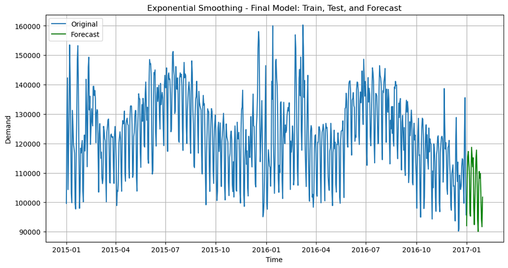

```python
from sklearn.metrics import mean_squared_error, mean_absolute_percentage_error
import numpy as np
from statsmodels.tsa.holtwinters import ExponentialSmoothing
import matplotlib.pyplot as plt



# Best parameters from hyperparameter tuning

alpha = 0.9950000  # Smoothing level
beta = 0.0001      # Smoothing trend
gamma = 0.0001     # Smoothing seasonality
trend = 'add'
seasonal = 'mul'
seasonal_periods = 154  # Seasonal period
damped_trend = False  # No damped trend

# Fit the final Exponential Smoothing model with the best parameters
model_final = ExponentialSmoothing(
    df['demand'],
    trend=trend,
    seasonal=seasonal,
    seasonal_periods=seasonal_periods,
    damped_trend=damped_trend,
    initialization_method='estimated'
)

# Fit the model with the fixed parameters
model_fit_final = model_final.fit(
    smoothing_level=alpha,
    smoothing_slope=beta,
    smoothing_seasonal=gamma,
    optimized=False  # Turn off automatic optimization as we are using fixed parameters
)

# Forecast for the next 30 days
forecast_final = model_fit_final.forecast(steps=30)

# Print the forecast
print("Forecast for the next 30 days using the final model:")
print(forecast_final)

# Plot the forecasted values
plt.figure(figsize=(12, 6))
plt.plot(df['demand'], label='Original')
plt.plot(forecast_final, label='Forecast', color='green')
plt.legend(loc='upper left')
plt.title('Exponential Smoothing - Final Model: Train, Test, and Forecast')
plt.xlabel('Time')
plt.ylabel('Demand')
plt.grid(True)
plt.show()
```